# 소프트맥스의 이해 및 차트

```python
# https://www.tensorflow.org/tutorials/keras/classification?hl=ko
```

```python
import gc
gc.collect()
```

```
47743
```

```python
import tensorflow as tf

# Helper libraries
import numpy as np
import matplotlib.pyplot as plt

print(tf.__version__)
```

```
2.9.1
```

```python
fashion_mnist = tf.keras.datasets.fashion_mnist
(train_images, train_labels), (test_images, test_labels) = fashion_mnist.load_data()
```

```python
class_names = ['T-shirt/top', 'Trouser', 'Pullover', 'Dress', 'Coat',
               'Sandal', 'Shirt', 'Sneaker', 'Bag', 'Ankle boot']
```

```python
train_images.shape,test_images.shape
```

```
((60000, 28, 28), (10000, 28, 28))
```

```
(array([0, 1, 2, 3, 4, 5, 6, 7, 8, 9], dtype=uint8), array([6000, 6000, 6000, 6000, 6000, 6000, 6000, 6000, 6000, 6000],
      dtype=int64))
(array([0, 1, 2, 3, 4, 5, 6, 7, 8, 9], dtype=uint8), array([1000, 1000, 1000, 1000, 1000, 1000, 1000, 1000, 1000, 1000],
      dtype=int64))
```

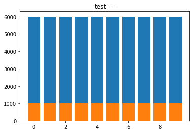

```python
# y값의 분포도
import matplotlib.pyplot as plt

def countF(data,title,op=0):
    tmp=np.unique(data, return_counts=True)
    print(tmp)
    plt.bar(tmp[0],tmp[1])
    plt.title(title)
    if op==1:
        plt.show()


countF(train_labels,'train')

countF(test_labels,'test----')
```

```python
def rangeChk(data):
    plt.figure()
    plt.imshow(data,cmap='gray')
    plt.colorbar()
    plt.grid(False)
    plt.show()

    # 이미지숫자의 범위를 확인하는 방법
    print(data.min(), '~',data.max())
```

[figure not shown]

```
0 ~ 255
```

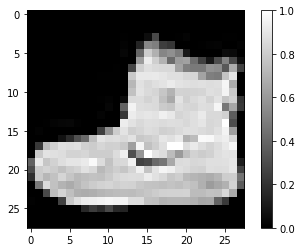

```
0.0 ~ 1.0
```

```python
rangeChk(train_images[0])

train_images = train_images / 255
test_images = test_images / 255

rangeChk(train_images[0])
```

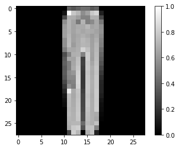

```
0.0 ~ 1.0
```

```python
rangeChk(train_images[1000])
```

[figure not shown]

```python
plt.figure(figsize=(20,10))
for i in range(25):
    plt.subplot(5,10,i+1)
    plt.xticks([])
    plt.yticks([])
    plt.grid(False)
    plt.imshow(train_images[i], cmap=plt.cm.binary)
    plt.xlabel(class_names[train_labels[i]])
plt.show()
```

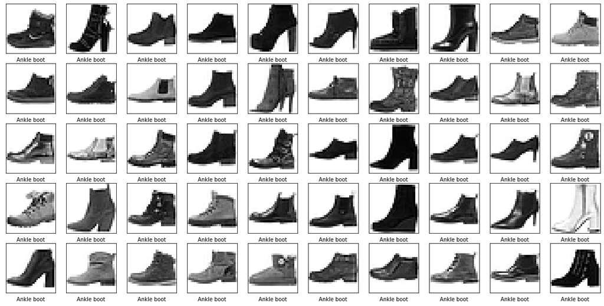

```python
# 구글검색, 복수의 인덱스값 찾기
# 아래코드는 컴프리핸션(압축)으로, 또는 람다로 바꿔서도 작업해야함.
findRow=[]
for cnt,x in enumerate(train_labels):
    if x==9:
        findRow.append(cnt)


plt.figure(figsize=(20,10))
for cnt,i in enumerate(findRow[:50]):
    plt.subplot(5,10,cnt+1)
    plt.xticks([])
    plt.yticks([])
    plt.grid(False)
    plt.imshow(train_images[i], cmap=plt.cm.binary)
    plt.xlabel(class_names[train_labels[i]])
plt.show()
```

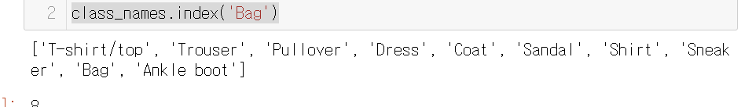

```python
print(class_names)
class_names.index('Bag')

60000/1875
```

```
['T-shirt/top', 'Trouser', 'Pullover', 'Dress', 'Coat', 'Sandal', 'Shirt', 'Sneaker', 'Bag', 'Ankle boot']
```

```
32.0
```

```python
model = tf.keras.Sequential([
    tf.keras.layers.Flatten(input_shape=(28, 28)),
    tf.keras.layers.Dense(128, activation='relu'),
    #tf.keras.layers.Dense(5, activation='relu'),
    tf.keras.layers.Dense(10)
])

model.compile(optimizer='adam',
              loss=tf.keras.losses.SparseCategoricalCrossentropy(from_logits=True),
              metrics=['accuracy'])
```

```python
import pandas as pd
hist = pd.DataFrame(history.history)
hist['epoch'] = history.epoch
hist.tail()
```

|  | loss | accuracy | val_loss | val_accuracy | epoch |
| --- | --- | --- | --- | --- | --- |
| 5 | 0.279698 | 0.896383 | 0.332025 | 0.8801 | 5 |
| 6 | 0.267876 | 0.900583 | 0.342069 | 0.8807 | 6 |
| 7 | 0.254949 | 0.904250 | 0.338738 | 0.8807 | 7 |
| 8 | 0.246948 | 0.907483 | 0.347733 | 0.8805 | 8 |
| 9 | 0.238418 | 0.910083 | 0.322846 | 0.8847 | 9 |

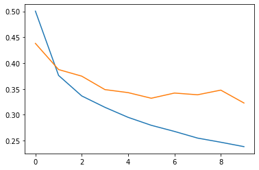

```python
plt.plot(hist.index,hist['loss'])
plt.plot(hist.index,hist['val_loss'])
```

```python
### 이 모델은 원핫인코딩을 하지 않고, 함수도 loss에서 ㅣogit으로 줌
```

```python
test_loss, test_acc = model.evaluate(test_images,  test_labels, verbose=2)

print('\nTest accuracy:', test_acc)
```

```
313/313 - 0s - loss: 0.3472 - accuracy: 0.8777 - 261ms/epoch - 834us/step

Test accuracy: 0.8776999711990356
```

```python
probability_model = tf.keras.Sequential([model,
                                         tf.keras.layers.Softmax()])
predictions = probability_model.predict(test_images)
```

```
('Trouser', 'Trouser')
```

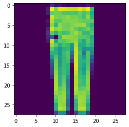

```python
bun=200
plt.imshow(test_images[bun])
class_names[np.argmax(predictions[bun])], class_names[test_labels[bun]]
```

[figure not shown]

```python
test_labels
result=[np.argmax(x) for x in predictions]

import pandas as pd
df = pd.DataFrame({'test:':test_labels, 'result':result, 'bigo':test_labels==result})
findRow=df[df['bigo']==False].index


plt.figure(figsize=(20,10))
for cnt,i in enumerate(findRow[:50]):
    plt.subplot(5,10,cnt+1)
    plt.xticks([])
    plt.yticks([])
    plt.grid(False)
    plt.imshow(test_images[i], cmap=plt.cm.binary)
    plt.xlabel(class_names[test_labels[i]]+ ' ▶ pr:' +class_names[df.iloc[i,1]])
plt.show()
```

```
0class error List
(array([2, 3, 4, 6, 7, 8], dtype=int64), array([14,  8,  5, 56,  2, 10], dtype=int64))
```

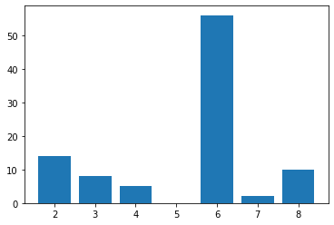

```
1class error List
(array([0, 2, 3, 4, 6, 8], dtype=int64), array([ 6,  2, 18,  3,  2,  3], dtype=int64))
```

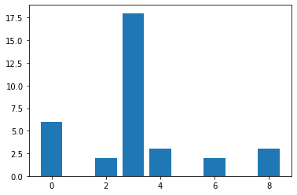

```
2class error List
(array([0, 1, 3, 4, 6, 8, 9], dtype=int64), array([ 23,   1,   4, 106,  41,   4,   1], dtype=int64))
```

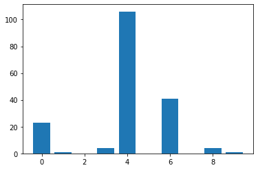

```
3class error List
(array([0, 1, 2, 4, 6, 8], dtype=int64), array([42,  6, 27, 72, 35,  7], dtype=int64))
```

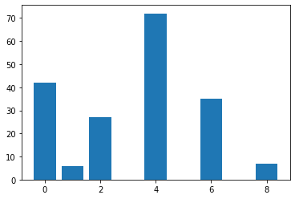

```
4class error List
(array([0, 1, 2, 3, 6, 8], dtype=int64), array([ 3,  1, 99, 11, 37,  3], dtype=int64))
```

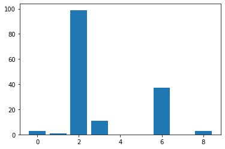

```
5class error List
(array([3, 7, 9], dtype=int64), array([ 1, 28, 25], dtype=int64))
```

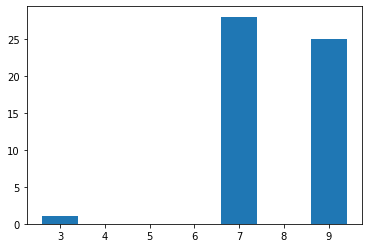

```
6class error List
(array([0, 2, 3, 4, 8], dtype=int64), array([188, 111,  14,  93,  14], dtype=int64))
```

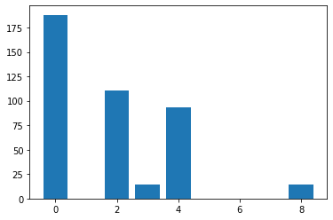

```
7class error List
(array([5, 9], dtype=int64), array([ 9, 34], dtype=int64))
```

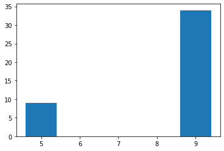

```
8class error List
(array([0, 2, 4, 5, 6, 7], dtype=int64), array([4, 5, 3, 3, 1, 3], dtype=int64))
```

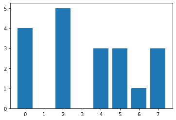

```
9class error List
(array([5, 6, 7], dtype=int64), array([ 5,  1, 29], dtype=int64))
```

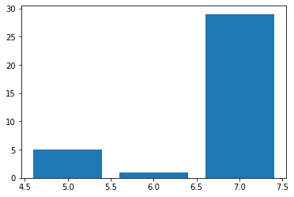

```python
test_labels
result=[np.argmax(x) for x in predictions]

import pandas as pd
df = pd.DataFrame({'test':test_labels, 'result':result, 'bigo':test_labels==result})
findRow=df[df['bigo']==False].index


errDf=df.iloc[findRow,:]
for x in range(10):
    print(str(x) + 'class error List')
    tmp=errDf[errDf['test']==x]
    tmpU=np.unique(tmp['result'],return_counts=True)
    print(tmpU)
    plt.bar(tmpU[0],tmpU[1])
    plt.show()
```

```python
print(np.unique(df['test'][df['bigo']==False],return_counts=True))
print('-'*100)

np.unique(df['result'][df['bigo']==False],return_counts=True)
```

```
(array([0, 1, 2, 3, 4, 5, 6, 7, 8, 9], dtype=uint8), array([ 95,  34, 180, 189, 154,  54, 420,  43,  19,  35], dtype=int64))
----------------------------------------------------------------------------------------------------
```

```
(array([0, 1, 2, 3, 4, 5, 6, 7, 8, 9], dtype=int64),
 array([266,   8, 258,  56, 282,  17, 173,  62,  41,  60], dtype=int64))
```

```
Sandal상품을 중고나라에 올리셨습니다.자동으로Sandal카테고리로 이동하겠습니다
```

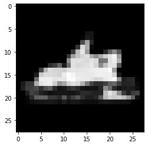

```python
from PIL import Image
img=Image.open('f_mnist_sample.jpg').convert('L')
img=img.resize((28,28))
img=np.array(img)
imgback=255-img
plt.imshow(imgback,cmap='gray')

primg=imgback/255.
reimg=np.reshape(primg, (1,28,28))


ca=class_names[np.argmax(probability_model(reimg))]
print(ca +'상품을 중고나라에 올리셨습니다.자동으로' + ca + '카테고리로 이동하겠습니다')
```

## 미션: 패션 mnist 모델에서 예측한 결과로 폴더 이동

- class_name별 폴더를 제작 (권장사항: cate폴더를 한개 만들고 그 하위에 10개의 class_name을 제작)
- img 폴더를 제작해서 그 안에 사진을 여러개 넣음
  - 예측결과를 높이고 싶다면 모델 학습에 사용되었던 사진과 비슷한 사진으로 작업
  - 예측결과는 상관없이 전체적인 걸 원한다면 어떤 사진이든 괜찮음
- img 폴더에서 첫번째 사진을 읽고 그 사진을 예측
  - 모델학습과 똑같은 상황을 만들어야됨.
    - (흑백, 28의28로 사이즈변경, 배경이 검정색이 되도록 처리)
    - ( /255. 으로 스케일링)
  - 예측모델은 (1,28,28)로 넣어줘야 함. (사진한장은 28,28이기때문에 맨 앞에 1,를 추가해야함)
  - 예측한 자료는 np.argmax 로서 가장 값이 큰 위치 index를 가져오고
  - 그 인덱스값을 class_names 에서 찾아서 결과물의 class_name을 확인함.
- 그 class_name으로 그 이미지를 이동또는 복사

## 미션

- 각 폴더별 데이터 갯수를 차트로 작성
- 일정한 폴더의 갯수가 30개가 넘으면 담당자에게 문자보내기

## 텐서 사이트 차트도 실행하고 해석

https://www.tensorflow.org/tutorials/keras/classification?hl=ko

### ▶참고: 모델 규모별 오버피팅 확인법

```python
## 사이즈별

baseline_model = tf.keras.Sequential([
    tf.keras.layers.Flatten(input_shape=(28, 28)),
    tf.keras.layers.Dense(128, activation='relu'),
    #tf.keras.layers.Dense(5, activation='relu'),
    tf.keras.layers.Dense(10)
])


# SparseCategoricalCrossentropy 는 y값을 원핫인코딩 안하고 softmax하고자할때
baseline_model.compile(optimizer='adam',
              loss=tf.keras.losses.SparseCategoricalCrossentropy(from_logits=True),
              metrics=['accuracy'])
baseline_history=baseline_model.fit(train_images, train_labels, epochs=10,
          validation_data=(test_images,test_labels),verbose=0)
```

```python
## 사이즈별

smaller_model = tf.keras.Sequential([
    tf.keras.layers.Flatten(input_shape=(28, 28)),
    tf.keras.layers.Dense(5, activation='relu'),
    #tf.keras.layers.Dense(5, activation='relu'),
    tf.keras.layers.Dense(10)
])


# SparseCategoricalCrossentropy 는 y값을 원핫인코딩 안하고 softmax하고자할때
smaller_model.compile(optimizer='adam',
              loss=tf.keras.losses.SparseCategoricalCrossentropy(from_logits=True),
                      metrics=['accuracy'])
smaller_history=smaller_model.fit(train_images, train_labels, epochs=10,
          validation_data=(test_images,test_labels),verbose=0)
```

```python
## 사이즈별

bigger_model = tf.keras.Sequential([
    tf.keras.layers.Flatten(input_shape=(28, 28)),
    tf.keras.layers.Dense(512, activation='relu'),
    #tf.keras.layers.Dense(5, activation='relu'),
    tf.keras.layers.Dense(10)
])


# SparseCategoricalCrossentropy 는 y값을 원핫인코딩 안하고 softmax하고자할때
bigger_model.compile(optimizer='adam',
              loss=tf.keras.losses.SparseCategoricalCrossentropy(from_logits=True),
                        metrics=['accuracy'])
bigger_history=bigger_model.fit(train_images, train_labels, epochs=10,
          validation_data=(test_images,test_labels),verbose=0)
```

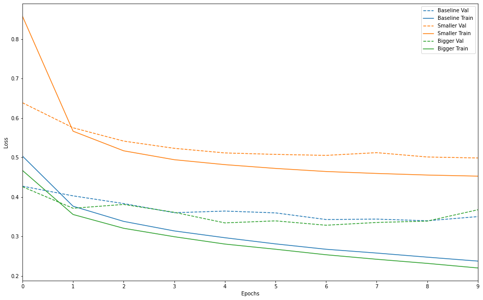

```python
def plot_history(histories, key='loss'):
  plt.figure(figsize=(16,10))

  for name, history in histories:
    val = plt.plot(history.epoch, history.history['val_'+key],
                   '--', label=name.title()+' Val')
    plt.plot(history.epoch, history.history[key], color=val[0].get_color(),
             label=name.title()+' Train')

  plt.xlabel('Epochs')
  plt.ylabel(key.replace('_',' ').title())
  plt.legend()

  plt.xlim([0,max(history.epoch)])


plot_history([('baseline', baseline_history),
              ('smaller', smaller_history),
              ('bigger', bigger_history)])
```

```python
#####  덴스층별

## 사이즈별
#del baseline_model
baseline_model = tf.keras.Sequential([
    tf.keras.layers.Flatten(input_shape=(28, 28)),
    tf.keras.layers.Dense(512, activation='relu',kernel_regularizer=tf.keras.regularizers.l2(0.001)),
    tf.keras.layers.Dense(512, activation='relu'),
    #tf.keras.layers.Dropout(0.5),
    tf.keras.layers.Dense(10)
])


# SparseCategoricalCrossentropy 는 y값을 원핫인코딩 안하고 softmax하고자할때
baseline_model.compile(optimizer='adam',
              loss=tf.keras.losses.SparseCategoricalCrossentropy(from_logits=True),
              metrics=['accuracy'])
baseline_history=baseline_model.fit(train_images, train_labels, epochs=20,
          validation_data=(test_images,test_labels),verbose=1,batch_size=200)
```

[output not shown]